# Tarea 13

Dalia Camacho

## 13-Modelos jerárquicos

En este ejercicio definirás un modelo jerárquico para la incidencia de tumores en grupos de conejos a los que se suministró una medicina. Se realizaron 71 experimentos distintos utilizando la misma medicina.

Considerando que cada conejo proviene de un experimento distinto, se desea estudiar $\theta_j$, la probabilidad de desarrollar un tumor en el $j$-ésimo grupo, este parámetro variará de grupo a grupo.

Denotaremos $y_{ij}$ la observación en el $i$-ésimo conejo perteneciente al $j$-ésimo experimento, $y_{ij}$ puede tomar dos valores: 1 indicando que el conejo desarrolló tumor y 0 en el caso contrario, por tanto la verosimilitud sería:

$$y_{ij} \sim Bernoulli(\theta_j)$$

Adicionalmente se desea estimar el efecto medio de la medicina a lo largo de los grupos $\mu$, por lo que utilizaremos un modelo jerárquico como sigue:

$$\theta_j \sim Beta(a, b)$$

donde

$$a=\mu \kappa$$
$$b=(1-\mu)\kappa$$

Finalmente asignamos una distribución a los hiperparámetros $\mu$ y $\kappa$,

$$\mu \sim Beta(A_{\mu}, B_{\mu})$$

$$\kappa \sim Gamma(S_{\kappa}, R_{\kappa})$$

1. Si piensas en este problema como un lanzamiento de monedas, ¿a qué corresponden las monedas y los lanzamientos? Los lanzamientos serían cada conejo y si tiene un tumor o no y las monedas serían los 71 experimentos.
2. Los datos en el archivo `rabbits.RData` contienen las observaciones de los 71 experimentos, cada renglón corresponde a una observación.
   - Utiliza JAGS o Stan para ajustar un modelo jerárquico como el descrito arriba y usando una inicial $Beta(1, 1)$ y una $Gamma(1, 0.1)$ para $\mu$ y $\kappa$ respectivamente.
   - Realiza un histograma de la distribución posterior de $\mu$, $\kappa$. Comenta tus resultados.

```r
library(tidyverse)
library(R2jags)
modelo_jer.bugs <-
'
model{
  for(t in 1:N){
    x[t] ~ dbern(theta[experiment[t]])
  }
  for(j in 1:nExperiments){
    theta[j] ~ dbeta(a, b)
  }
  a <- mu * kappa
  b <- (1 - mu) * kappa
  # A_mu = 1, B_mu = 1
  mu ~ dbeta(1, 1)
  kappa ~ dgamma(1, 0.1)
}
'

cat(modelo_jer.bugs, file = 'modelo_jer.bugs')
```

```r
load("rabbits.RData")
x          <- rabbits$tumor
experiment <- rabbits$experiment

jags.inits <- function(){
  list("mu" = runif(1, 0.1, 0.9),
    "kappa" = runif(1, 5, 20))
}

jags_fit <- jags(
  model.file = "modelo_jer.bugs",    # modelo de JAGS
  inits = jags.inits,   # valores iniciales
  data = list(x = x, experiment = experiment, nExperiments = 71,  N = 1810),    # lista con los datos
  parameters.to.save = c("mu", "kappa", "theta"),  # parámetros por guardar
  n.chains = 3,   # número de cadenas
  n.iter = 10000,    # número de pasos
  n.burnin = 1000   # calentamiento de la cadena
  )
```

```
## module glm loaded
```

```r
#
jags_fit
```

```
## Inference for Bugs model at "modelo_jer.bugs", fit using jags,
##  3 chains, each with 10000 iterations (first 1000 discarded), n.thin = 9
##  n.sims = 3000 iterations saved
##            mu.vect sd.vect     2.5%      25%      50%      75%    97.5%
## kappa       31.670  10.406   16.260   24.289   29.857   37.347   56.255
## mu           0.183   0.012    0.160    0.175    0.183    0.192    0.209
## theta[1]     0.128   0.047    0.044    0.094    0.126    0.157    0.228
## theta[2]     0.127   0.047    0.046    0.092    0.123    0.157    0.232
## theta[3]     0.128   0.048    0.047    0.093    0.124    0.157    0.232
## theta[4]     0.127   0.047    0.046    0.093    0.124    0.158    0.230
## theta[5]     0.127   0.046    0.049    0.092    0.123    0.157    0.226
## theta[6]     0.127   0.046    0.049    0.094    0.124    0.155    0.227
## theta[7]     0.128   0.048    0.047    0.093    0.124    0.158    0.233
## theta[8]     0.130   0.048    0.048    0.096    0.126    0.156    0.238
## theta[9]     0.130   0.049    0.048    0.095    0.125    0.159    0.237
## theta[10]    0.130   0.048    0.048    0.095    0.126    0.160    0.231
## theta[11]    0.129   0.048    0.047    0.095    0.125    0.159    0.237
## theta[12]    0.133   0.050    0.050    0.097    0.128    0.164    0.244
## theta[13]    0.133   0.049    0.050    0.097    0.128    0.164    0.243
## theta[14]    0.135   0.049    0.049    0.099    0.131    0.166    0.242
## theta[15]    0.148   0.050    0.063    0.112    0.144    0.178    0.256
## theta[16]    0.147   0.050    0.064    0.111    0.142    0.178    0.256
## theta[17]    0.147   0.050    0.062    0.111    0.141    0.179    0.253
## theta[18]    0.146   0.049    0.061    0.111    0.142    0.179    0.251
## theta[19]    0.150   0.051    0.064    0.114    0.146    0.182    0.260
## theta[20]    0.150   0.052    0.063    0.112    0.145    0.182    0.263
## theta[21]    0.154   0.052    0.067    0.117    0.149    0.185    0.266
## theta[22]    0.152   0.051    0.066    0.116    0.146    0.183    0.266
## theta[23]    0.165   0.049    0.080    0.129    0.162    0.196    0.270
## theta[24]    0.150   0.048    0.067    0.116    0.146    0.181    0.255
## theta[25]    0.155   0.050    0.069    0.120    0.150    0.186    0.259
## theta[26]    0.157   0.050    0.072    0.122    0.154    0.188    0.266
## theta[27]    0.167   0.053    0.080    0.129    0.162    0.201    0.284
## theta[28]    0.165   0.053    0.076    0.128    0.160    0.196    0.284
## theta[29]    0.165   0.052    0.076    0.128    0.161    0.196    0.281
## theta[30]    0.168   0.053    0.076    0.131    0.164    0.201    0.282
## theta[31]    0.166   0.053    0.076    0.130    0.162    0.197    0.281
## theta[32]    0.166   0.054    0.073    0.128    0.163    0.198    0.284
## theta[33]    0.182   0.061    0.081    0.138    0.176    0.220    0.311
## theta[34]    0.143   0.040    0.073    0.114    0.140    0.168    0.230
```

[output cut: 105 more lines]

```
## theta[65] 1.001  2800
## theta[66] 1.001  3000
## theta[67] 1.001  3000
## theta[68] 1.001  3000
## theta[69] 1.001  2300
## theta[70] 1.002  1100
## theta[71] 1.001  3000
## deviance  1.001  3000
##
## For each parameter, n.eff is a crude measure of effective sample size,
## and Rhat is the potential scale reduction factor (at convergence, Rhat=1).
##
## DIC info (using the rule, pD = var(deviance)/2)
## pD = 53.6 and DIC = 1751.1
## DIC is an estimate of expected predictive error (lower deviance is better).
```

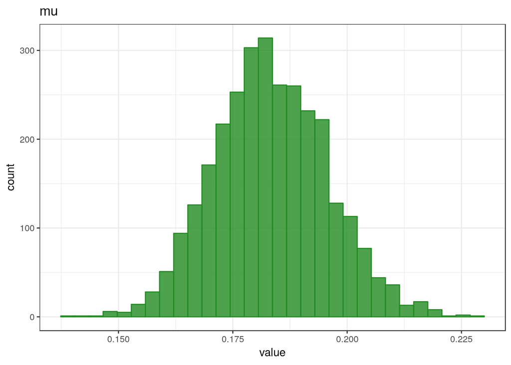

```r
sims_df <- data.frame(n_sim = 1:jags_fit$BUGSoutput$n.sims,
  jags_fit$BUGSoutput$sims.matrix) %>%
  dplyr::select(-deviance) %>%
  gather(parametro, value, -n_sim)

ggplot(filter(sims_df, parametro =="mu"), aes(x = value)) +theme_bw()+
  geom_histogram(alpha = 0.8, bins=30,
                 col="forestgreen", fill="forestgreen")+
  ggtitle("mu")
```

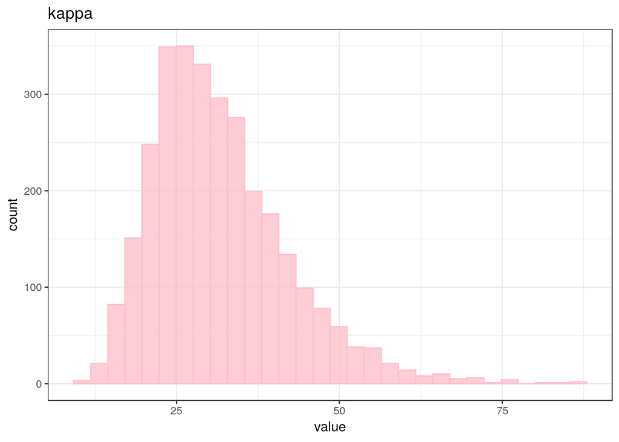

```r
ggplot(filter(sims_df, parametro =="kappa"), aes(x = value)) +theme_bw()+
  geom_histogram(alpha = 0.8, bins=30,
                 col="pink", fill="pink")+
  ggtitle("kappa")
```

```r
modelo_jer2.bugs <-
'
model{
  for(t in 1:N){
    x[t] ~ dbern(theta[experiment[t]])
  }
  for(j in 1:nExperiments){
    theta[j] ~ dbeta(a, b)
  }
  a <- mu * kappa
  b <- (1 - mu) * kappa
  # A_mu = 1, B_mu = 1
  mu ~ dbeta(10, 10)
  kappa ~ dgamma(0.51, 0.001)
}
'

cat(modelo_jer2.bugs, file = 'modelo_jer2.bugs')
```

```r
jags.inits <- function(){
  list("mu" = runif(1, 0.1, 0.9),
    "kappa" = runif(1, 5, 20))
}

jags_fit2 <- jags(
  model.file = "modelo_jer2.bugs",    # modelo de JAGS
  inits = jags.inits,   # valores iniciales
  data = list(x = x, experiment = experiment, nExperiments = 71,  N = 1810),    # lista con los datos
  parameters.to.save = c("mu", "kappa", "theta"),  # parámetros por guardar
  n.chains = 3,   # número de cadenas
  n.iter = 10000,    # número de pasos
  n.burnin = 1000   # calentamiento de la cadena
  )
#
jags_fit2
```

```
## Inference for Bugs model at "modelo_jer2.bugs", fit using jags,
##  3 chains, each with 10000 iterations (first 1000 discarded), n.thin = 9
##  n.sims = 3000 iterations saved
##            mu.vect sd.vect     2.5%      25%      50%      75%    97.5%
## kappa       97.931 139.678   21.915   37.684   54.192   88.502  541.416
## mu           0.188   0.011    0.166    0.180    0.188    0.195    0.211
## theta[1]     0.150   0.043    0.069    0.120    0.151    0.180    0.231
## theta[2]     0.150   0.043    0.067    0.121    0.150    0.178    0.232
## theta[3]     0.151   0.044    0.064    0.120    0.151    0.180    0.237
## theta[4]     0.150   0.044    0.065    0.119    0.150    0.179    0.236
## theta[5]     0.150   0.044    0.066    0.119    0.151    0.179    0.237
## theta[6]     0.150   0.044    0.065    0.120    0.151    0.179    0.235
## theta[7]     0.150   0.044    0.063    0.120    0.150    0.181    0.235
## theta[8]     0.151   0.044    0.066    0.120    0.151    0.179    0.240
## theta[9]     0.153   0.043    0.066    0.123    0.153    0.181    0.236
## theta[10]    0.151   0.043    0.068    0.122    0.151    0.180    0.233
## theta[11]    0.152   0.044    0.067    0.123    0.152    0.180    0.238
## theta[12]    0.153   0.044    0.069    0.124    0.154    0.183    0.237
## theta[13]    0.154   0.043    0.072    0.125    0.156    0.183    0.244
## theta[14]    0.156   0.044    0.070    0.125    0.157    0.185    0.244
## theta[15]    0.163   0.043    0.082    0.134    0.162    0.190    0.252
## theta[16]    0.163   0.043    0.080    0.133    0.163    0.190    0.249
## theta[17]    0.163   0.044    0.083    0.133    0.163    0.191    0.252
## theta[18]    0.163   0.043    0.082    0.132    0.163    0.189    0.251
## theta[19]    0.166   0.044    0.083    0.136    0.165    0.193    0.257
## theta[20]    0.166   0.044    0.083    0.135    0.167    0.194    0.256
## theta[21]    0.167   0.043    0.084    0.139    0.168    0.194    0.257
## theta[22]    0.165   0.043    0.081    0.137    0.166    0.193    0.252
## theta[23]    0.173   0.042    0.096    0.145    0.172    0.198    0.258
## theta[24]    0.167   0.043    0.087    0.138    0.166    0.192    0.256
## theta[25]    0.167   0.042    0.085    0.138    0.167    0.195    0.254
## theta[26]    0.169   0.043    0.090    0.141    0.169    0.196    0.258
## theta[27]    0.176   0.044    0.093    0.146    0.174    0.202    0.269
## theta[28]    0.176   0.044    0.096    0.148    0.174    0.203    0.275
## theta[29]    0.176   0.043    0.095    0.147    0.176    0.204    0.261
## theta[30]    0.177   0.044    0.096    0.148    0.176    0.203    0.269
## theta[31]    0.177   0.044    0.095    0.148    0.175    0.203    0.270
## theta[32]    0.175   0.044    0.092    0.146    0.174    0.202    0.269
## theta[33]    0.186   0.050    0.097    0.152    0.182    0.215    0.295
## theta[34]    0.158   0.036    0.088    0.133    0.157    0.182    0.232
```

[output cut: 105 more lines]

```
## theta[65] 1.006   370
## theta[66] 1.002  1500
## theta[67] 1.010   220
## theta[68] 1.005   420
## theta[69] 1.004   600
## theta[70] 1.005   420
## theta[71] 1.002  1000
## deviance  1.015   170
##
## For each parameter, n.eff is a crude measure of effective sample size,
## and Rhat is the potential scale reduction factor (at convergence, Rhat=1).
##
## DIC info (using the rule, pD = var(deviance)/2)
## pD = 95.8 and DIC = 1805.4
## DIC is an estimate of expected predictive error (lower deviance is better).
```

[figure not shown]

```r
sims_df2 <- data.frame(n_sim = 1:jags_fit2$BUGSoutput$n.sims,
  jags_fit$BUGSoutput$sims.matrix) %>%
  dplyr::select(-deviance) %>%
  gather(parametro, value, -n_sim)

ggplot(filter(sims_df2, parametro =="mu"), aes(x = value)) +theme_bw()+
  geom_histogram(alpha = 0.8, bins=30,
                 col="forestgreen", fill="forestgreen")+
  ggtitle("mu")
```

[figure not shown]

```r
ggplot(filter(sims_df2, parametro =="kappa"), aes(x = value)) +theme_bw()+
  geom_histogram(alpha = 0.8, bins=30,
                 col="pink", fill="pink")+
  ggtitle("kappa")
```

```r
meansTheta1 <- sims_df %>%group_by(parametro) %>%
  summarise(meansTheta1=mean(value))
meansTheta2 <- sims_df2 %>%group_by(parametro) %>%
  summarise(meansTheta1=mean(value))
```

[figure not shown]

```r
ggplot()+theme_bw()+
  geom_point(aes(meansTheta1$meansTheta1[3:73], meansTheta2$meansTheta1[3:73]),
             col="navyblue")+
  xlab("Modelo 1")+ylab("Modelo 2")+
  ggtitle("Comparación de modelos")
```